# Coursework Report

*N* removed NAs: 2

*N* removed typo: 1

*N* removed <18: 22

*N* total clean: 125

| Group | *N* | *M*<sub>age</sub> | *M*<sub>rating</sub> |
| --- | --- | --- | --- |
| Control | 58 | 20.8 | 6.51 |
| Experim | 67 | 20.4 | 5.73 |

**Main analysis results**

*t*(123) = 5.41, *p* < .001

[interactive chart not shown]

[figure not shown]

[interactive chart not shown]

# Coursework Report

Analysing Data, Spring 2020

# Methods

## Design

The conceptual hypothesis is - does colour influence attractiveness?

Colour is am independent categorical variable. Participants each saw one of two pictures in a frame. The white frame was the control and the red frame was the experimental condition.

Attractiveness is a rating, consisting of 1 to 9 on three different questions. 1 being not attractive at all and 9 being very attractive. The three questions include (Elliot et al., 2010):

“How attractive do you think this person is?” “How pleasant is this person to look at?” “If i were to meet this person in this picture face to face, I would think he is attractive.”

The operational hypothesis is as follows, does viewing a differen colour frame on an image of a man influence the mean rating of the man’s attractiveness?

A Two-Sample t-test statistical analysis will be used to test the operational hypothesis.

# Results

The research question asks whether there is a relationship between colour and attractiveness. Therefore, a one means plot of compostive score by colour group was conducted with colour as the predictor and attractiveness as the outcome.

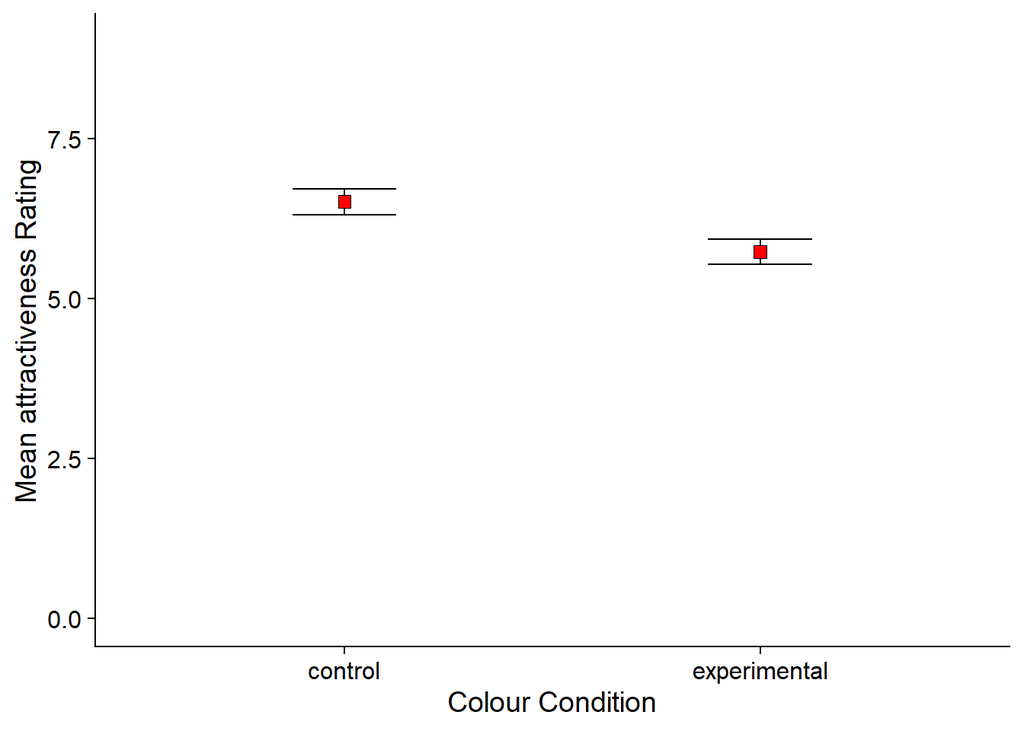

The graph reveals that the control condition has an overall higher rating attractiveness that the experimental condition as it has a hgiher mean attractiveness rating. This means that participants actually found the men more attractive in a white frame, rather than in a red frame. The hypothesis is thus supported as it proved that colour or the lack of, influences attractiveness.

# Discussion

The results show that colour has an influence on attractiveness. The resulys are in concordance with the original stody by Elliot et al. (2010). The pattern of results were slightly different but this may be because of the difference in sample size and the number of questions asked. Francis (2013) highlights the issue that conclusions reached from the experiments alone, are too haste and may not have enough ground to form a relationship. This paper agrees with Francis (2013) and mentions the experiments to be too reliant on qualitative data in the limitations below.

There are too few question asked, which can make the data set not varied enough or valid enough. The quantative data collected is very much based on subjective personal views and can render invalid. Due to the unethical ages and invalid ages in the original data set, the proceeding data set is redundant as it may not represent the original population. As the participants answer the questions, their previous answers might influence the later answers and result in the data being unreliable.

It was good that at least 3 questions were asked. It may perhaps provides enough variance. It was also good that the data set had removed unethical ages and blank ages which overall increased the reliability and validity of the data set. The usage of one colour as the variable was also favourable as it allowed for a reliable focus of results and for a true relationship to be determined. The use of a colourless white is also good as explained by Elliot et al. (2010) as it wouldn’t hinder the effct that the colour red might have had.

This data can be used as the introduction into colour psychology and relational psychology in general. It could provide further insight onto the actual relationship of red and attractiveness and raise any questions whether any other colour has the same influence on attractiveness or other physical attributes and phenomena. This study also raises further points of reseach into sexuality and attractiveness. It would be ineteresting to consider whether sexuality influences attractiveness whether it makes participants more biased or not.

# References

Elliot, A. J., Niesta Kayser, D., Greitemeyer, T., Lichtenfeld, S., Gramzow, R. H., Maier, M.A., & Liu, H. (2010). Red, rank, and romance in women viewing men. *Journal of Experimental Psychology: General, 139*(3), 399.

Francis, G. (2013). *Publication Bias in “Red, Rank, and Romance in Women Viewing Men,” by Elliot Et Al. (2010), 142*(1), 292-296.